# Assessing incomplete sampling of disease transmission networks

March 13, 2019

## Colaborators

- Work that I have done with the Pathogen and Microbiome Institute at NAU and we are just a couple months into the project.

[figure not shown]

- Dr Paul Keim
- Dr Jason Sahl

## Background Information

## Two worrisome Healthcare Aquired Infections (HAIs)

- MRSA
  - Methicillin-resistant Staphylococcus aureus
  - Resistant to many common antibiotics
- *C. Diff*
  - *Clostridioides difficile*
  - Our disease of interest

## *Clostridioides difficile*

- A spore-forming bacteria
  - Spores can survive for months in the environment
  - Bacteria die when exposed to oxygen.
  - Very difficult to work with in the lab.
- *C. diff* is widely distributed
  - Spores are widely found in the environment
  - People and animals can be asymptomatic carriers
- Resistant to many commonly used antibiotics

## Human Infection

- Causes diarrhea, fever, nausea, and abdominal pain
- Spread through fecal contamination
- Additional $4.8 billion each year in health care costs
  - 290,000 Americans sickened by the bacteria in a hospital or other health care facility each year.
  - 27,000 people in the U.S. die while infected with *C. diff* annually.

## Common infection cycle

- In a healthy gut biome, *C. diff* can’t strongly establish due to bacterial competition.
- In patients under a common antibiotic treatment, *C. diff* can flourish.
- Prescribed antibiotics for some other reason (e.g. pneumonia)
  - *C. diff* might already be present in the patient.
  - Come into contact with *C. diff* via live bacteria or spores from another patient.

## Medicare Implications

- Won’t reimburse costs for treating infections acquired at a healthcare facility
- If the rate of Healthcare Acquired Infections (HAIs) is too high, Medicare will deduct one percent from their OVERALL reimbursements to the facility.
- Medicare defines any diagnosis of *C. diff* that occurs 3 days after admission as “healthcare acquired”.

## Goal: Estimate HAI rate

- Individual patients have the genome of their strain of *C. diff* sequenced.
- Group strains into clusters if they differ by at most 2 SNPs.
  - Use Single-Linkage clustering method: represents evolution along a chain of infections
  - Within patient variability suggests that maybe this needs to be evaluated.

## Data!

## Oxfordshire Data

- Eyre *et al* 2013 describes a study which genotyped nearly all cases of *C. diff* in over three years in Oxfordshire, UK.
- Of the 1250 cases that were evaluated, \(N=1223\) were successfully genotyped.

## Oxfordshire Time/Clusters

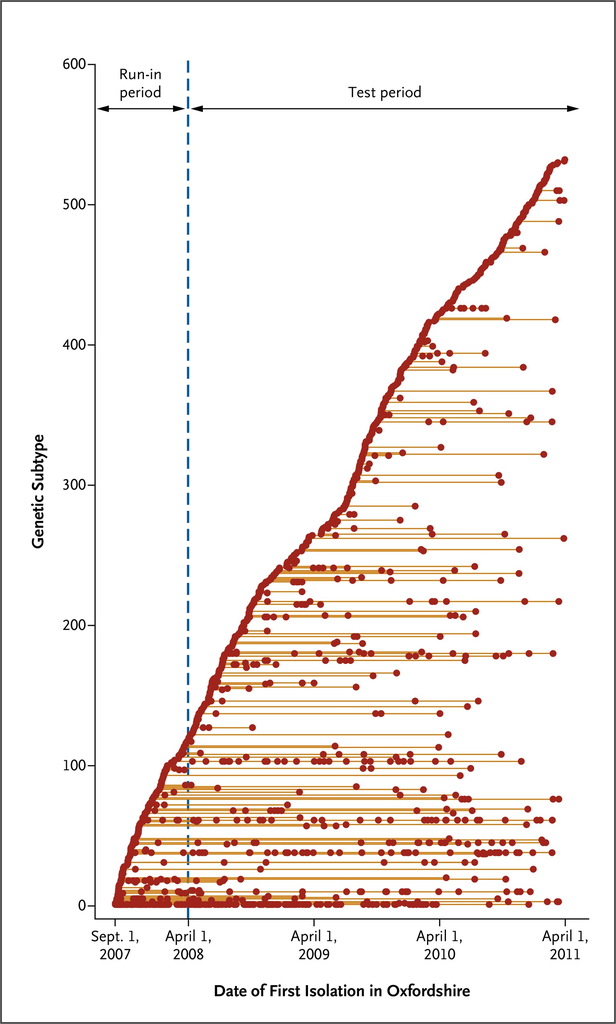

## Oxfordshire Cluster Size Distribution

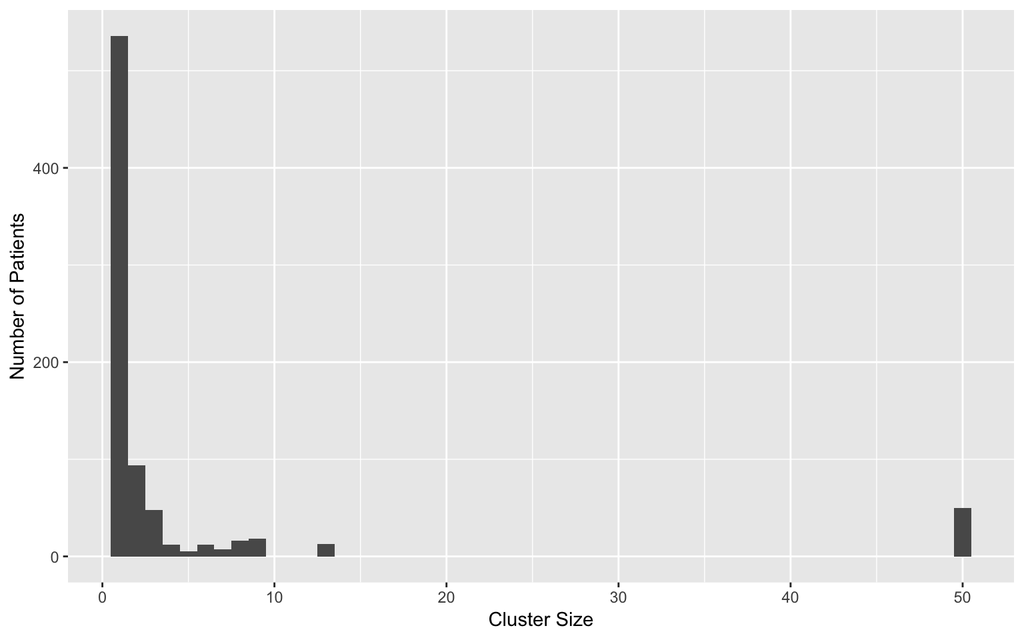

## Defining HAI rate from full data

- For each cluster, the first time a strain is observed it is considered environmentally acquired.
- The second (or third, or fourth, ..) time a strain is observed, it is healthcare acquired.

\[HAI = \frac{N - ||\mathcal{I}||}{N} = 1 - \frac{||\mathcal{I}||}{N}\] \[ N = \textrm{ Number of Patients }\] \[\mathcal{I} = \textrm{ Set of strain identifiers }\] \[||\mathcal{I}|| = \textrm{ Actual Number of Clusters/Strains }\]

- Knowing \(||\mathcal{I}||\) is the key to calculating HAI rate!

## Observed Number of Clusters/Strains under Simple Random Sampling

\[ \widehat{HAI}_{naive} = 1 - \frac{||I||}{n} \] \[ n = \textrm{ sample size } \] \[ I = \textrm{ Set of observed strains }\] \[ ||I|| = \textrm{ Observed Number of Clusters/Strains } \]

## Does the Naive Estimator Work?

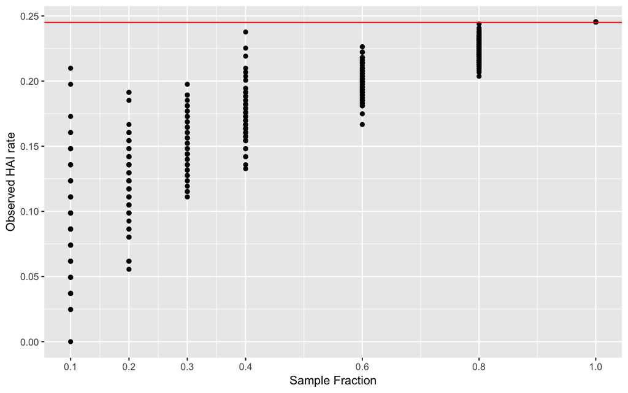

## Why doesn’t this work?

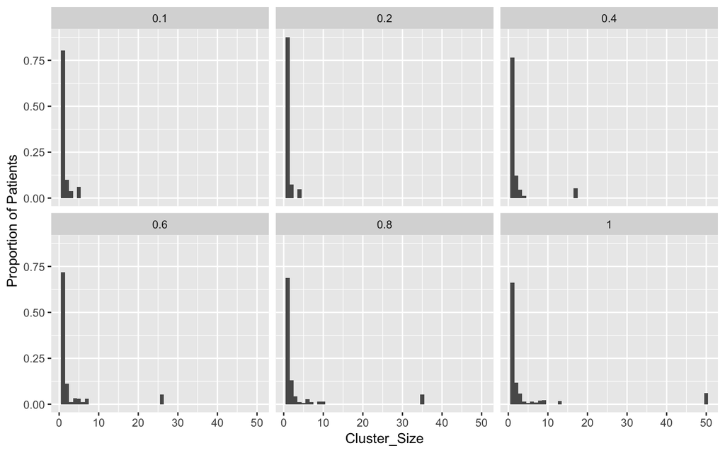

## Better Estimators?

## HyperGeometric?

- Let
  - \(n_i\) be the number of patients with strain \(i\). (This is unknown!)
  - \(m_i\) be the observed number of patients with strain \(i\).
  - \(\alpha\) be the sampling percentage.

\[n_i \stackrel{iid}{\sim} \textrm{ZTPoisson}(\lambda) \; \textrm{for} \; i\in \mathcal{I}\]

\[m_i | n_i \sim \textrm{ZTHyperGeometric}(n_i, \; N-n_i, \;\alpha N) \; \textrm{for}\; i \in I\]

\[ E(m_i | n_i) = \left(1-f(0|n_i)\right)^{-1} \;\alpha \;n_i\]

where \(I\) is a subset of \(\mathcal{I}\) and the ZT represents the zero truncated distributions.

## HyperGeometric?

\[f(0|n_i) = \frac{ {n_i \choose 0}{N-n_i \choose \alpha N} }{ {N \choose \alpha N}}\]

\[E[m_i] = E[ E(m_i|n_i)] = E[ (1-f(0|n_i))^{-1} \;\alpha \;n_i]\]

## Can we just ignore the expectation?

One estimator is to ignore the expectation and solve the following equation for \(\widehat{n}_i\). \[ m_i = (1-f(0|\widehat{n}_i))^{-1} \;\alpha \; \widehat{n}_i\] which needs to be solved via numerical methods because the “chooses” in \(f(0|\widehat{n}_i)\).

\[ \widehat{HAI}_{hyper} = 1 - \frac{||I||}{\widehat{n}} \] \[ \widehat{n} = \sum \widehat{n}_i \] \[ I = \textrm{ Set of observed strains }\] \[ ||I|| = \textrm{ Observed Number of Clusters/Strains } \]

## Species Abundance Methods

- A well studied problem is estimating the total number of species based on repeated surveys.
- Each patient represents a survey, which might produce a new strain, or one that has already been seen.
- Several estimators for this problem
  - Chao, Jacknife1, Jacknife2, Bootstrap
  - I’ll show Chao and Jacknife
- Used `vegan::specpool`

## Estimators of Oxford Data

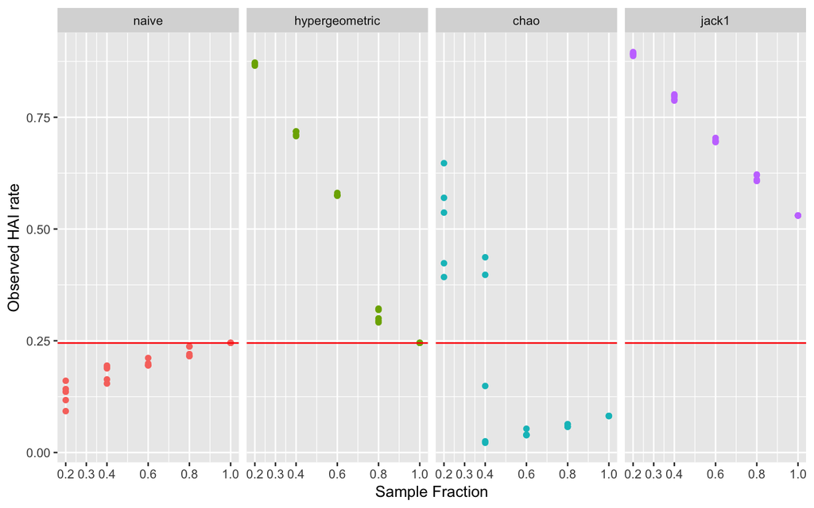

## Simulated Populations

- The Oxfordshire data could be reasonably modeled using a mixture of two distributions to separate the small clusters sizes from the large. We chose to model the small clusters sizes using a truncated Poisson distribution with the zero truncated out. The large cluster sizes were modeled from a logNormal distribution.

\[n_i \sim \begin{cases} \textrm{TPoisson}(\lambda) & \textrm{ with probability } 1 - \alpha \\ \textrm{logNormal}(\mu, \sigma) &\textrm{ with probability } \alpha \end{cases}\]

for \(i\) in \(\mathcal{I}\).

## Simulated Populations

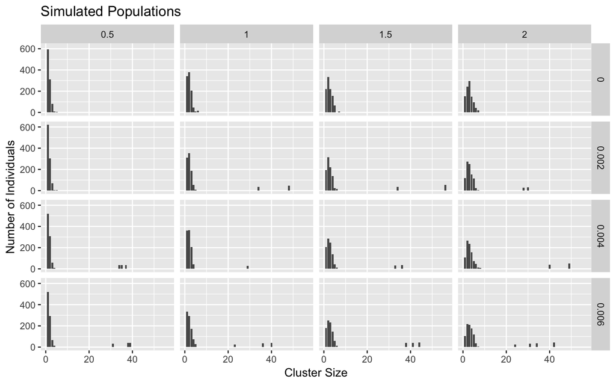

## Simulated Data: Naive method

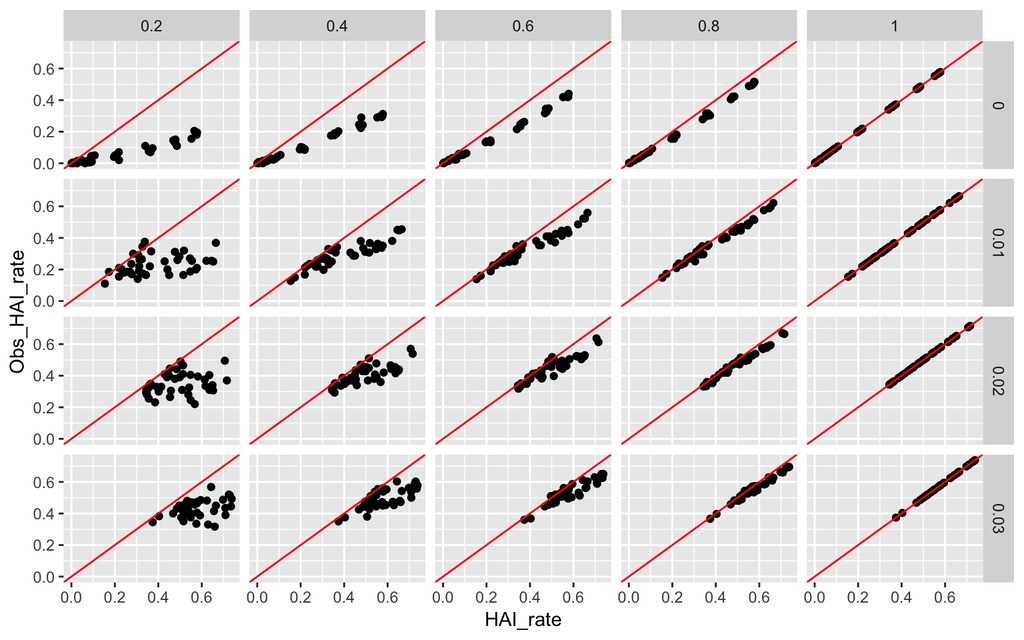

## Simulated Data: Chao

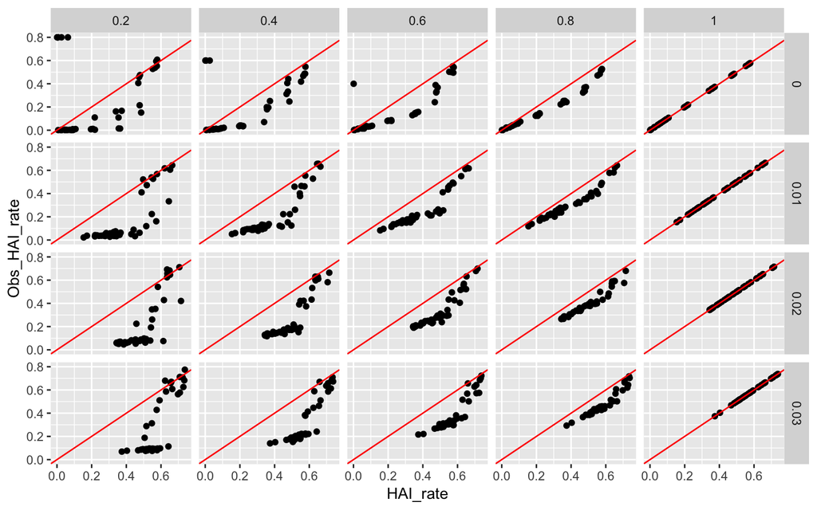

## Simulated Data: Hypergeometric

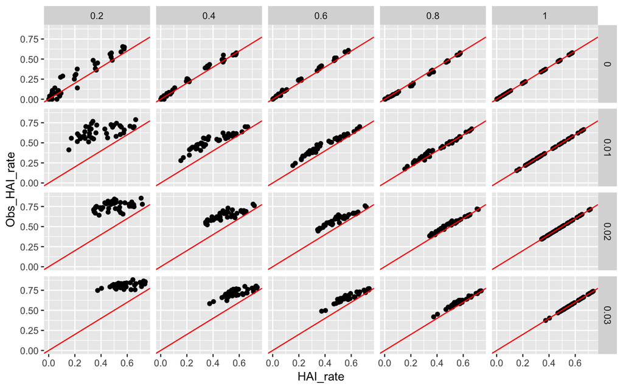

## Next Steps

- Improve Large Cluster Estimation
  - Evaluate \[E\left[ {N-n_i \choose \alpha N} \alpha \;n_i \right]\]
  - Stirling’s Approximation?
  - Needs some assumptions about distribution of \(n_i\).
- Confidence Interval for HAI
  - Bootstrap clusters or patients?